# Main IT - Univariate analysis

Fabio Torreggiani

Created: 2nd November 2023; Updated: 15th December 2023

Purpose: Running descriptive analysis on all the measured variables, divided by mechanism and, when needed, compared with either the reference population.

# Summary

- **Representativity of the sample**. Representative of gender and more or less of age (slightly younger), but not representative at all in terms of education: much more educated than the general population. Sinistra Ecologia e Libertà and Movimento 5 Stelle oversampled.
- **Twitter**. Half of the sample has it and uses it regularly, especially for lurking (78% at least once a week; 50% for active use).
- **Cognitive effort**. Tasks where quite difficult: 50% of sample got 0 correct, another 25% got just one correct and only around 10% got all correct.
- **Politics**. Party affiliation is relatively similar to that of general population, especially accounting for the coding mistake on Forza Italia. Left-Right orientation present a quasi-normal distribution, with anchoring on the extremes and at the center.
- **Institutions**. Pretty low trust, with all institutions with mean below middle point of the scale, except for Universities. Social media have the lowest trust (mean 0.3/1). Government the one with highest SD (polarized as expected), but not radically different from others. In general, Press, Parliament and Government have the more similar distributions. Trust in science is pretty high according to both measures. Other considerations in PCA report.
- **Anti-elitism**. Distributions are squeezed over the top of the scale in all cases: most people chose extremely high answers. The least concentrated distributions is that of third item (politicians listen to people), which also have some answers in the middle and low part of he scale. This item is also the one that is more strongly (negatively) correlated with trust in political institutions. The opposite is true for second item (difference between people and elite).
- **Social Norms - Beliefs**. Not a clear preference for accuracy, but a bi-modal distribution: accuracy and interest are at the exact same level. This is not the case for personal normative beliefs, where there is a clear preference for accuracy (while interest mantain the second place not far behind). This is an indication that participants understood the questions and that there is a fraction of people recognizing that they value interest when they should value accuracy.
- **Social Norms - Expectations**. People are quite good at guessing the “unclear/mixed” situation regarding the norm. The mode answer is “more or less half of the sample”, followed by “around a quarter”. This result is true for both empirical and normative expectations and it is the same as in the Italian convenience sample. Also, there is a link between beliefs and expectations, but not a very strong one: the incidence of “accuracy” is higher in “almost everyone”.
- **Media Consumption**. The most consumed media are internet, phones and tv news, which are consumed more ore less by everyone and on a very frequent base. Other media are more “niche”, in the sense that they have both people using them a lot and others using them never or very rarely: newspaper, radionews, social media and emails. Friends are consumed by more or less everyone, but with varying frequency.
- **Perceived Accuracy**. Sort of bi-modal, but not coinciding with the two extremes: “extremely accurate” is the least chosen category. In general, people were both skeptical (generally low scores, even for reliable news) and good at discerning news (still, there is a gap between fake and reliable news).
- **Perceived Accuracy - Events**. Differently to what noted in other studies, people were good at discerning news, independently of the event analysed. For 17 out of 20 events the reliable news is significantly perceived as more accurate than the fake news. Then, there are two events for which the scores are not statistically distinguishable between the true and fake news. Finally, there is an event (event 20, like in the other 2 studies) for which the perc. acc. is higher for the fake than the reliable news. This result could also be simply due to the higher numerosity of the sample.
- **Perceived Accuracy - Round and Treatment**. No effect of round: people are not better (nor worse) as the survey proceed. No effect of treatment: truth discernment is not better or worse after the treatment, in none of the groups.
- **Robustness Checks - Individual Perceived Accuracy**. In general, the distribution is very close to a normal one. Divided by veracity, the curve for fake news is squeezed toward the bottom of the scale and seems “cut”: a lot of people choose the bottom of the scale for fake news. Individual truth discernment present a normal distribution with high kurtosis and a relatively weak right skewness.
- **Robustness Checks - Balance of news**. The balance of news (% of fake news over the ten items) is a normal distribution (randomization worked correctly). There is no effect of balance on truth discernment: people judged items one by one, without inferring the balance of true vs fake news and trying to guess the accuracy based on that.
- **Sharing behavior**. As expected, it is a very rare behaviour and linked with perceived accuracy (correlation of 0.64).

# Demographics

## Age

```r
part_df$DEM_AGE %>% summary()
```

```
##    Min. 1st Qu.  Median    Mean 3rd Qu.    Max.    NA's
##      18      34      47      46      58      85      16
```

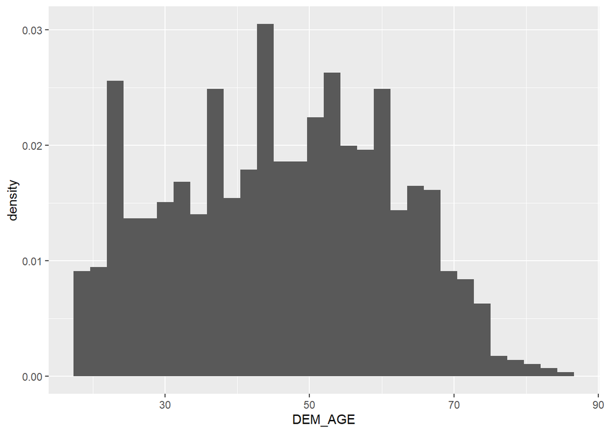

```r
part_df %>% ggplot(aes(x = DEM_AGE)) +
  geom_histogram(aes(y = ..density..)) +
  stat_function(fun = ~dnorm(.x,
                             mean = mean(part_df$DEM_AGE),
                             sd = sd(part_df$DEM_AGE)))
```

```r
part_df$DEM_AGECat %>% table() %>% prop.table()
```

```
## .
##  18-24  25-34  35-44  45-54 55plus
##   0.10   0.15   0.19   0.22   0.33
```

### Comparison with general population

Source: [Istat](https://demo.istat.it/app/?i=POS&l=it)

```r
# General population data
genpop_df_AGe <- read.csv("C:/Users/fabio/Documents/Universita/Dottorato/Survey anti-el socnorm/data analysis/general population data/Italy/age_gender_IT.csv")
names(genpop_df_AGe) <- c("DEM_AGE", "Uomo", "Donna", "Total")

min_age = summary(part_df$DEM_AGE)[[1]]
max_age = summary(part_df$DEM_AGE)[[6]]
```

```r
# Building dataset for plot
temp_df <- part_df$DEM_AGECat %>% table() %>% prop.table() %>% as.data.frame()
names(temp_df) <- c("DEM_AGECat", "Frequency")

temp_df2 <- genpop_df_AGe %>%
  # filtering non-numerical rows
  filter(!DEM_AGE %in% c("Totale", "100 e oltre"),
         # filtering by same ages of sample
                         as.numeric(DEM_AGE) >= min_age &
                           as.numeric(DEM_AGE) <= max_age) %>%
  # collapsing into age categories
  mutate(DEM_AGECat = ifelse(DEM_AGE >= min_age & DEM_AGE < 25, "18-24",
                         ifelse(DEM_AGE >= 25 & DEM_AGE < 35, "25-34",
                                ifelse(DEM_AGE >= 35 & DEM_AGE < 45, "35-44",
                                       ifelse(DEM_AGE >= 45 & DEM_AGE < 55, "45-54", "55plus"))))) %>%
  # creating total and frequency by age group
  group_by(DEM_AGECat) %>% summarise(Total = sum(Total)) %>% mutate(TotPop = sum(Total), GenPop = Total/TotPop)
```

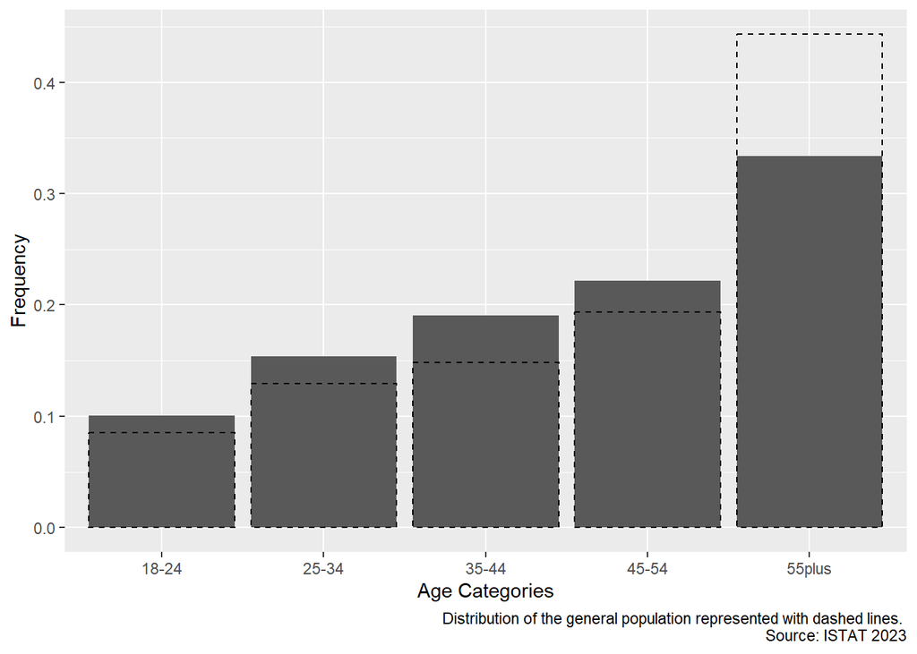

```r
# Visualization
temp_df %>% inner_join(select(temp_df2, DEM_AGECat, GenPop)) %>%
  ggplot(aes(x = DEM_AGECat, y = Frequency)) +
  geom_col() +
  geom_col(aes(y = GenPop), alpha = 0.25, linetype = "dashed", fill = NA, color = "black") +
  labs(x = "Age Categories", caption = "Distribution of the general population represented with dashed lines. \nSource: ISTAT 2023")
```

## Gender

```r
part_df$DEM_GENDER %>% table() %>% prop.table()
```

```
## .
##                                   Uomo                                  Donna
##                                 0.4896                                 0.5032
##        Genere non-binario/Terzo genere Preferisco identificarmi personalmente
##                                 0.0032                                 0.0008
##                   Preferisco non dirlo
##                                 0.0032
```

### Comparison with general population

Source: [Istat](https://demo.istat.it/app/?i=POS&l=it)

```r
# Building dataset for plot
temp_df <- table(part_df$DEM_GENDER) %>% as.data.frame() %>% filter(Var1 %in% c("Uomo", "Donna"))
names(temp_df) <- c("DEM_GENDER", "GroupSum")

temp_df2 <- genpop_df_AGe %>%
  # filtering by same ages of sample
  filter(as.numeric(DEM_AGE) >= min_age &
           as.numeric(DEM_AGE) <= max_age) %>%
  pivot_longer(col = 2:3,
               names_to = "DEM_GENDER") %>%
  group_by(DEM_GENDER) %>% summarise(
    GroupSum = sum(value)
  ) %>% mutate(Tot = sum(GroupSum), GenPop = GroupSum/Tot)
```

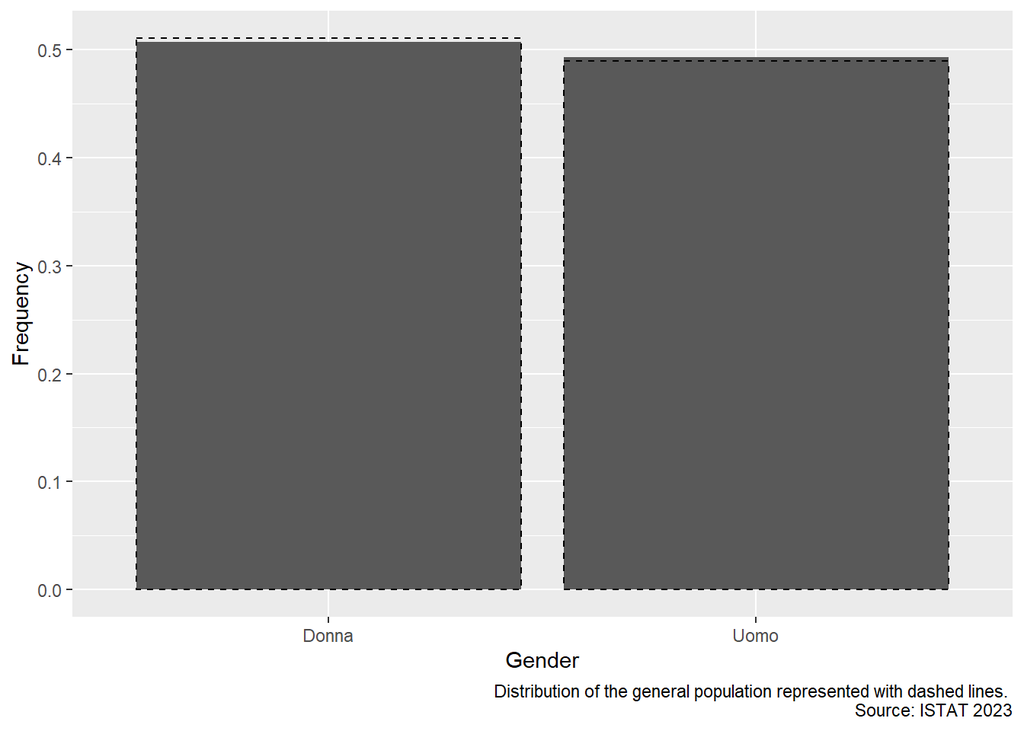

```r
# Visualization
temp_df %>% mutate(Tot = sum(GroupSum), Frequency = GroupSum/Tot) %>%
  inner_join(select(temp_df2, DEM_GENDER, GenPop), by = "DEM_GENDER") %>%
  ggplot(aes(x = DEM_GENDER, y = Frequency)) +
  geom_col() +
  geom_col(aes(y = GenPop), alpha = 0.25, linetype = "dashed", fill = NA, color = "black") +
  labs(x = "Gender", caption = "Distribution of the general population represented with dashed lines. \nSource: ISTAT 2023")
```

## Education

```r
part_df$DEM_EDU4Cat %>% table() %>% prop.table()
```

```
## .
## MiddleSchool   HighSchool     Bachelor       Master
##        0.092        0.494        0.176        0.238
```

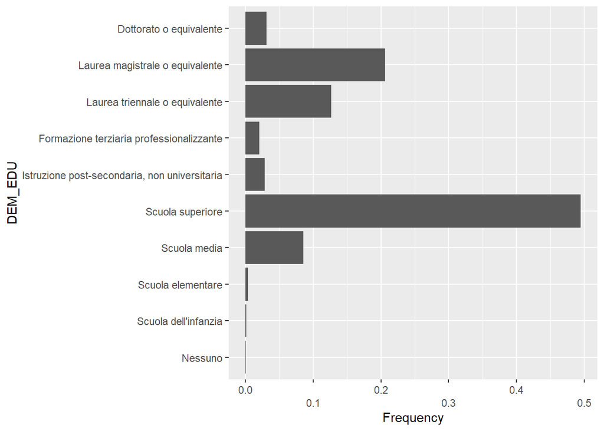

```r
part_df %>% ggplot(aes(x = DEM_EDU)) +
  geom_bar(aes(y = after_stat(count/sum(count)))) +
  guides(x = guide_axis(n.dodge = 2)) +
  labs(y = "Frequency") +
  coord_flip()
```

### Comparison with general population

Source: [ISTAT 2020](http://dati.istat.it/Index.aspx?QueryId=55980)

```r
# General population data
genpop_df_Edu <- read.csv("C:/Users/fabio/Documents/Universita/Dottorato/Survey anti-el socnorm/data analysis/general population data/Italy/education_IT.csv") %>% filter(`Seleziona.periodo` == "2020") %>% select(Titolo.di.studio, Value)
names(genpop_df_Edu) <- c("DEM_EDUCat", "GroupTot")
```

```r
# Building dataset for plot
temp_df <- part_df$DEM_EDU4Cat %>% as_factor() %>% fct_collapse(
  MiddleOrLower = c("MiddleSchool"),
  BachOrHigher = c("Bachelor", "Master")
) %>% table() %>% as.data.frame()
names(temp_df) <- c("DEM_EDUCat", "GroupSum")


genpop_df_Edu$DEM_EDUCat <- genpop_df_Edu$DEM_EDUCat %>% as_factor() %>% fct_collapse(
  MiddleOrLower = c("licenza di scuola elementare, nessun titolo di studio", "licenza di scuola media"),
  HighSchool = c("diploma"),
  BachOrHigher = c("laurea e post-laurea")
)
temp_df2 <- genpop_df_Edu %>% group_by(DEM_EDUCat) %>% summarise(GroupTot = sum(GroupTot)) %>% mutate(GenPop = GroupTot/sum(GroupTot))
```

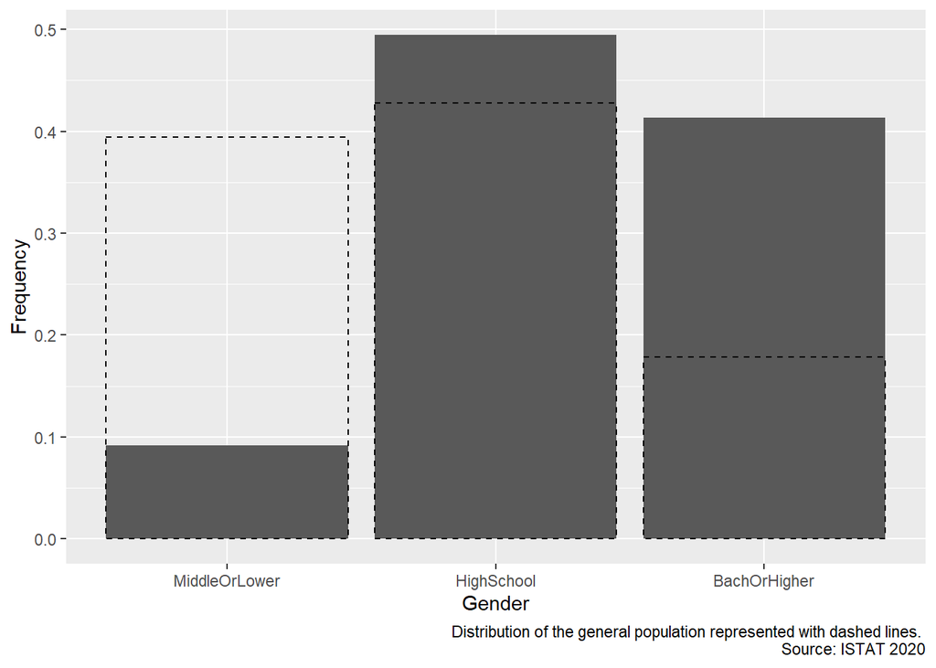

```r
# Visualization
temp_df %>% mutate(Frequency = GroupSum/sum(GroupSum)) %>%
  inner_join(select(temp_df2, DEM_EDUCat, GenPop), by = "DEM_EDUCat") %>%
  ggplot(aes(x = DEM_EDUCat, y = Frequency)) +
  geom_col() +
  geom_col(aes(y = GenPop), alpha = 0.25, linetype = "dashed", fill = NA, color = "black") +
  labs(x = "Gender", caption = "Distribution of the general population represented with dashed lines. \nSource: ISTAT 2020")
```

## Profession

```r
var_n = "DEM_PROF"
part_df[[var_n]] %>% table() %>% prop.table()
```

```
## .
##                                       Manager
##                                        0.0857
##                                Professionista
##                                        0.1241
##                     Tecnico/a specializzato/a
##                                        0.0552
##                                   Impiegato/a
##                                        0.4051
## Professione in attività commerciali e servizi
##                                        0.0440
##                 Lavoro agricolo specializzato
##                                        0.0088
##                                   Artigiano/a
##                                        0.0176
##                                     Operaio/a
##                                        0.0865
##                          Altro lavoro manuale
##                                        0.0248
##                                      Militare
##                                        0.0080
##  Non ho ancora esercitato nessuna professione
##                                        0.1401
```

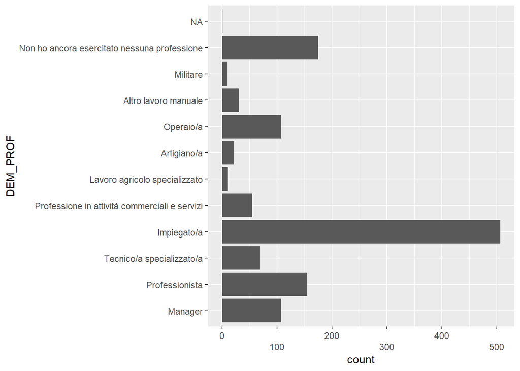

```r
part_df %>% ggplot(aes(x = part_df[[var_n]])) +
  geom_bar() +
  guides(x = guide_axis(n.dodge = 2)) +
  labs(x = var_n) +
  coord_flip()
```

```r
#+
  #geom_text(aes(label = after_stat(count)), stat = "count", vjust = -0.5, colour = "black")
```

# Twitter

## Have

```r
var_n = "TWH"
part_df[[var_n]] %>% table() %>% prop.table()
```

```
## .
##   Sì   No
## 0.42 0.58
```

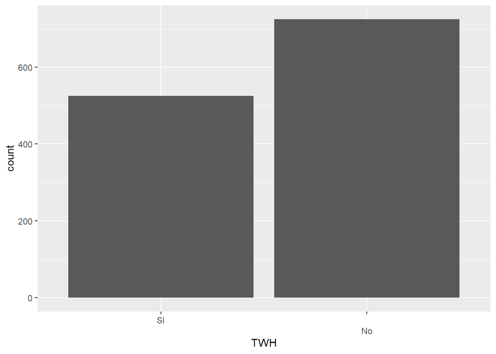

```r
part_df %>% ggplot(aes(x = .data[[var_n]])) +
  geom_bar() +
  guides(x = guide_axis(n.dodge = 2)) +
  labs(x = var_n) #+
```

```r
  #geom_text(aes(label = after_stat(count)), stat = "count", vjust = -0.5, colour = "black")
```

## Lurk

```r
var_n = "TWLURK"
part_df[[var_n]] %>% table() %>% prop.table()
```

```
## .
##                         Mai          Una volta all'anno
##                       0.034                       0.036
## Una volta ogni qualche mese           Una volta al mese
##                       0.082                       0.068
##    Una volta alla settimana       2-3 volte a settimana
##                       0.135                       0.181
##       4-6 volte a settimana   Una o più volte al giorno
##                       0.122                       0.341
##   Preferisco non rispondere
##                       0.002
```

```r
# Cumulative sum
part_df[[var_n]] %>% table() %>% rev() %>% prop.table() %>% cumsum()
```

```
##   Preferisco non rispondere   Una o più volte al giorno
##                       0.002                       0.343
##       4-6 volte a settimana       2-3 volte a settimana
##                       0.464                       0.645
##    Una volta alla settimana           Una volta al mese
##                       0.781                       0.849
## Una volta ogni qualche mese          Una volta all'anno
##                       0.930                       0.966
##                         Mai
##                       1.000
```

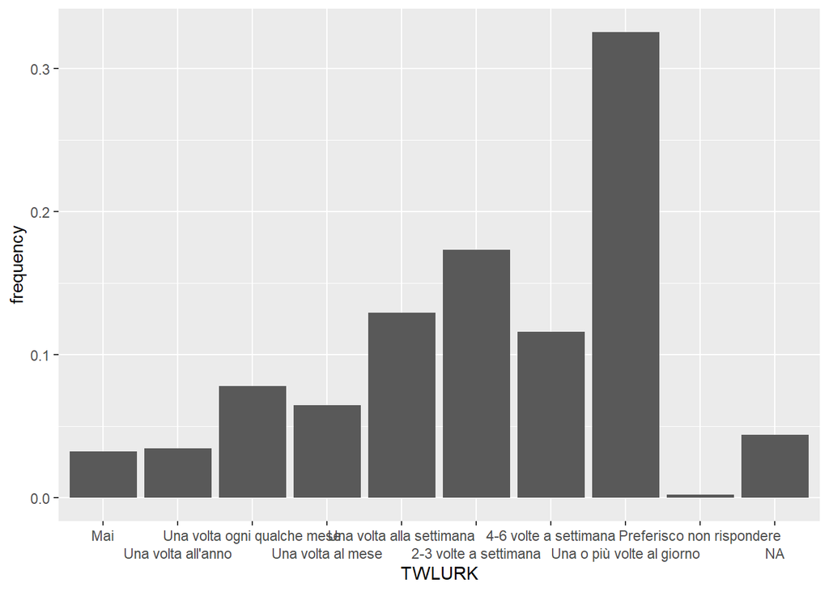

```r
part_df %>% filter(TWH == "Sì") %>%
  ggplot(aes(x = .data[[var_n]])) +
  geom_bar(aes(y = (..count..)/sum(..count..))) +
  guides(x = guide_axis(n.dodge = 2)) +
  labs(x = var_n, y = "frequency")
```

## Interact

```r
var_n = "TWACTIVE"
part_df[[var_n]] %>% table() %>% prop.table()
```

```
## .
##                         Mai          Una volta all'anno
##                       0.156                       0.074
## Una volta ogni qualche mese           Una volta al mese
##                       0.140                       0.120
##    Una volta alla settimana       2-3 volte a settimana
##                       0.098                       0.180
##       4-6 volte a settimana   Una o più volte al giorno
##                       0.090                       0.138
##   Preferisco non rispondere
##                       0.002
```

```r
# Cumulative sum
part_df[[var_n]] %>% table() %>% rev() %>% prop.table() %>% cumsum()
```

```
##   Preferisco non rispondere   Una o più volte al giorno
##                       0.002                       0.140
##       4-6 volte a settimana       2-3 volte a settimana
##                       0.230                       0.411
##    Una volta alla settimana           Una volta al mese
##                       0.509                       0.629
## Una volta ogni qualche mese          Una volta all'anno
##                       0.770                       0.844
##                         Mai
##                       1.000
```

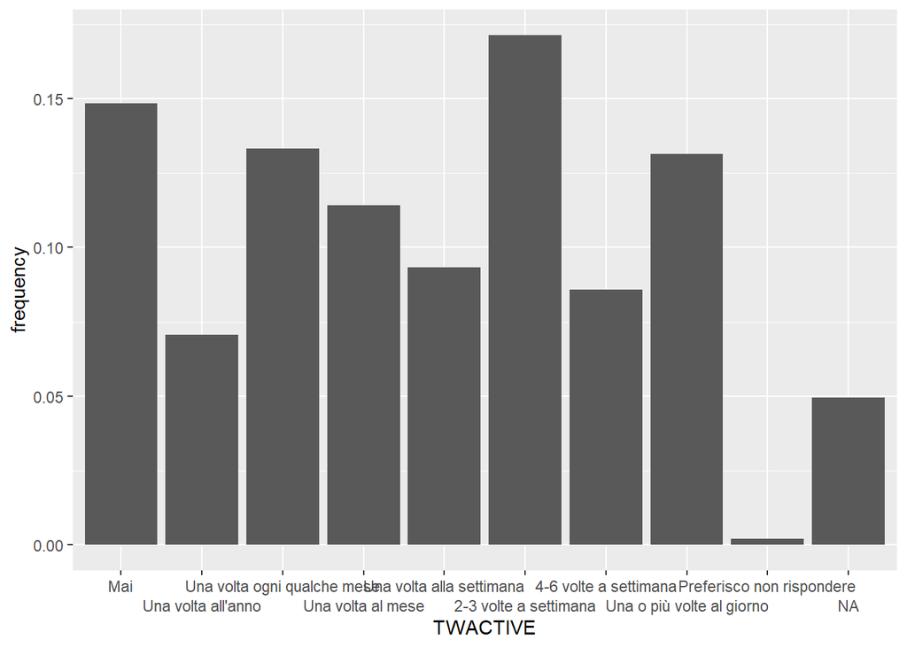

```r
part_df %>% filter(TWH == "Sì") %>%
  ggplot(aes(x = .data[[var_n]])) +
  geom_bar(aes(y = (..count..)/sum(..count..))) +
  guides(x = guide_axis(n.dodge = 2)) +
  labs(x = var_n, y = "frequency")
```

# Cognitive Tasks

```r
part_df$CRT %>% table() %>%
  transform(cumFreq = cumsum(Freq),
            relative = prop.table(Freq),
            cumRel = cumsum(prop.table(Freq)))
```

```
##      . Freq cumFreq relative cumRel
## 1    0  624     624     0.50   0.50
## 2 0.33  303     927     0.24   0.74
## 3 0.67  181    1108     0.14   0.89
## 4    1  142    1250     0.11   1.00
```

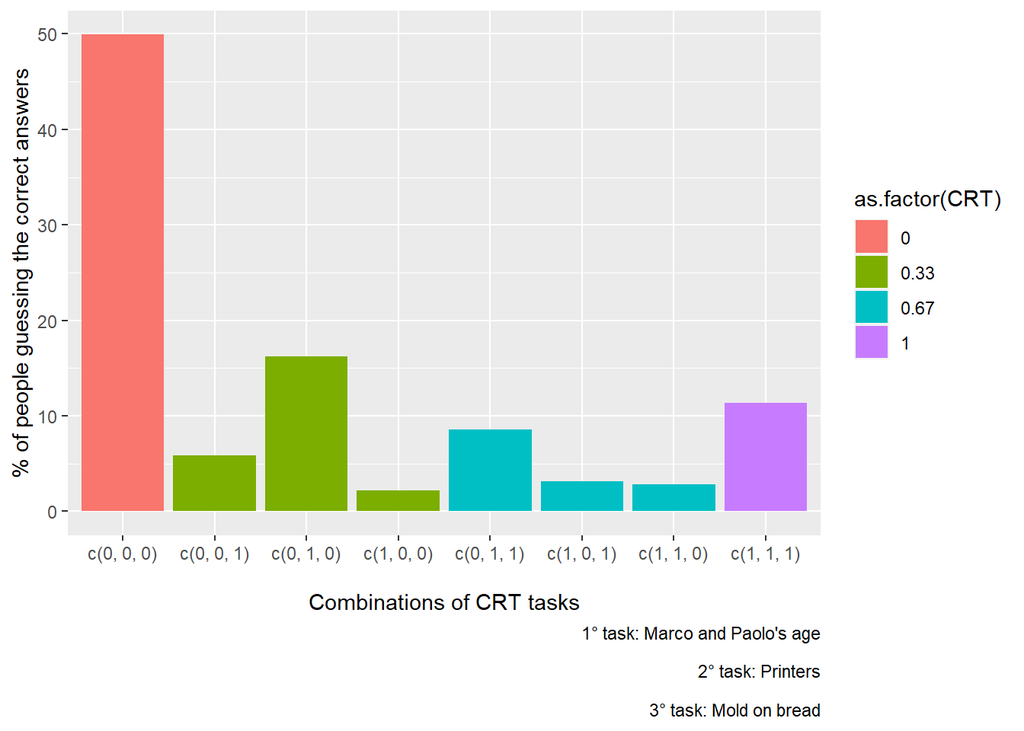

```r
temp_df <- part_df %>% group_by(CRT, COGT1Corr, COGT2Corr, COGT3Corr) %>%
  count() %>% mutate(
  comb = as.character(mapply(c, COGT1Corr, COGT2Corr, COGT3Corr, SIMPLIFY = F)),
  perc = n/nrow(part_df)
)
temp_df %>% ggplot(aes(x = fct_reorder(as.factor(comb), CRT), y = perc*100, fill = as.factor(CRT))) +
  geom_col() +
  labs(x = "\nCombinations of CRT tasks",
       y = "% of people guessing the correct answers",
       caption = "1° task: Marco and Paolo's age\n
       2° task: Printers\n
       3° task: Mold on bread")
```

```r
  #geom_text(aes(n), label = n, vjust = -0.5, colour = "black")
```

# Politics & Ideologies

## Political Consistency

### In general

```r
var_n = "POL_Cons"
answ_df[[var_n]] %>% table() %>% prop.table()
```

```
## .
##      Neutral   Consistent Inconsistent
##         0.63         0.20         0.17
```

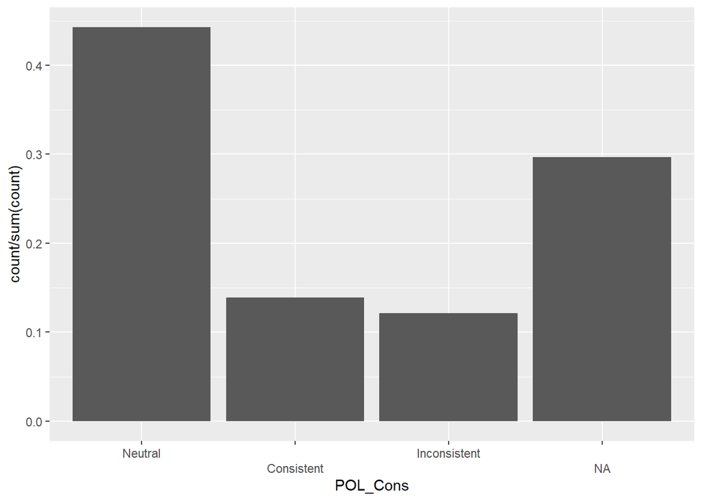

```r
answ_df %>% ggplot(aes(x = .data[[var_n]])) +
  geom_bar(aes(y = after_stat(count / sum(count)))) +
  guides(x = guide_axis(n.dodge = 2)) +
  labs(x = var_n)
```

### Per veracity

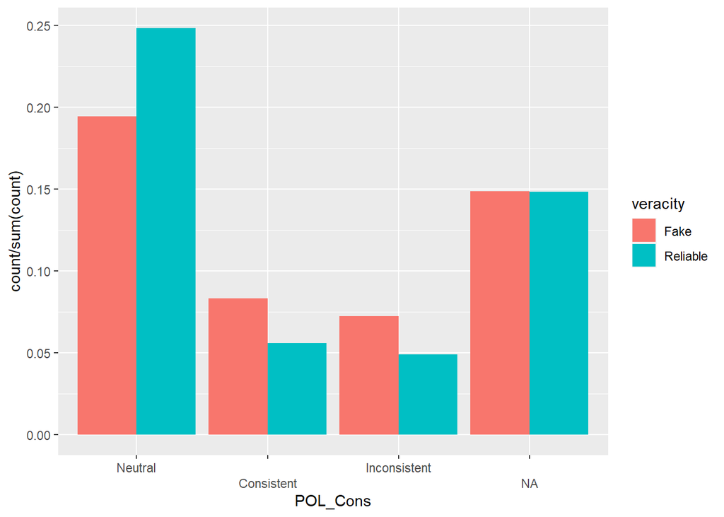

```r
answ_df %>% ggplot(aes(x = .data[[var_n]])) +
  geom_bar(aes(y = after_stat( count/sum(count) ),
               fill = veracity),
           position = "dodge") +
  guides(x = guide_axis(n.dodge = 2)) +
  labs(x = var_n)
```

### Per post

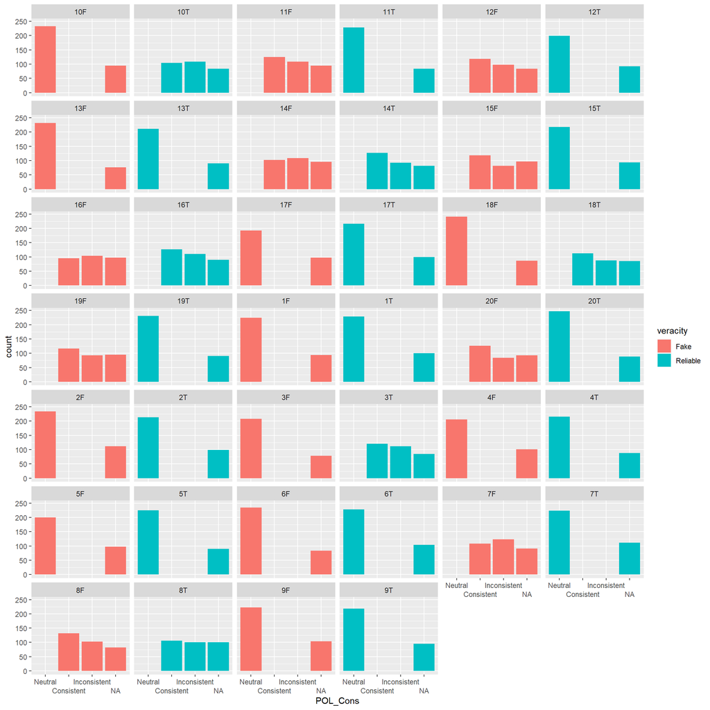

```r
answ_df %>% ggplot(aes(x = .data[[var_n]])) +
  geom_bar(aes(fill = veracity), position = "dodge") +
  guides(x = guide_axis(n.dodge = 2)) +
  labs(x = var_n) +
  facet_wrap(~(image), ncol = 6)
```

## Party affiliation

```r
var_n = "POL_party"
part_df[[var_n]] %>% table() %>% prop.table()
```

```
## .
##  Sin. It./Eur. Verde           Part. Dem.            PiùEuropa
##                0.066                0.136                0.029
##               Azione          Italia Viva        Mov. 5 Stelle
##                0.024                0.032                0.147
##                 Lega    Fratelli d'Italia       Nessun partito
##                0.066                0.201                0.246
## Pref. non rispondere
##                0.053
```

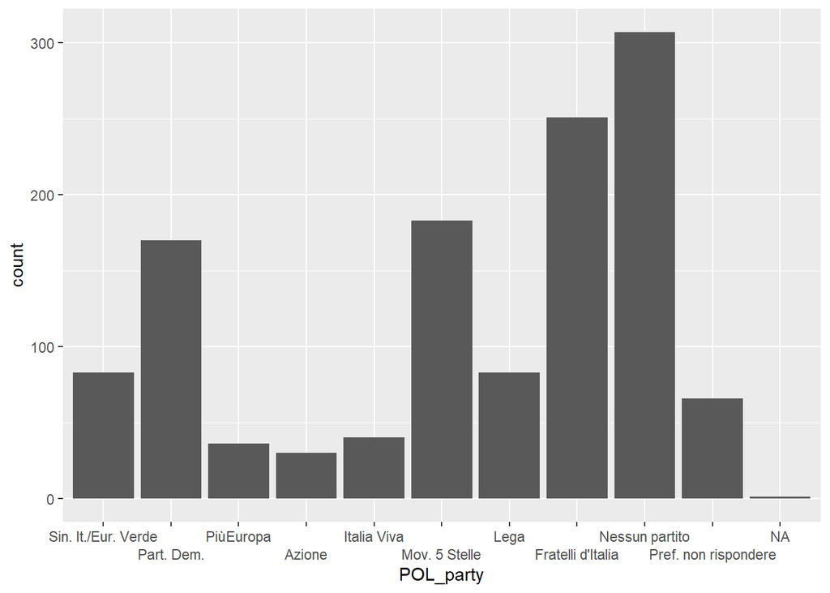

```r
part_df %>% ggplot(aes(x = .data[[var_n]])) +
  geom_bar() +
  guides(x = guide_axis(n.dodge = 2)) +
  labs(x = var_n)
```

### Party Affiliation - Without Abstention

```r
var_n = "POL_party"
part_df[[var_n]][part_df$POL_party != "Con nessun partito" & part_df$POL_party != "Preferisco non rispondere"] %>% table() %>% prop.table()
```

```
## .
##  Sin. It./Eur. Verde           Part. Dem.            PiùEuropa
##                0.066                0.136                0.029
##               Azione          Italia Viva        Mov. 5 Stelle
##                0.024                0.032                0.147
##                 Lega    Fratelli d'Italia       Nessun partito
##                0.066                0.201                0.246
## Pref. non rispondere
##                0.053
```

### Comparison with General Population

Source: [Supermedia YouTrend](https://www.youtrend.it/2023/10/27/supermedia-youtrend-agi-fdi-al-289-pd-al-197/) (manually transcribed into csv). Istituti considerati: Demopolis (data di pubblicazione: 23 ottobre), Eumetra (19 ottobre), Euromedia (22 e 24 ottobre), Noto (17 ottobre), Quorum (23 ottobre), SWG (16 e 23 ottobre) e Tecnè (14 e 21 ottobre).

```r
# General population data
genpop_df_PolPar <- read.csv2("C:/Users/fabio/Documents/Universita/Dottorato/Survey anti-el socnorm/data analysis/general population data/Italy/pol_party_IT.csv")
names(genpop_df_PolPar) <- c("POL_party", "GenPop")
```

```r
# Building dataset for plot
temp_df <- part_df$POL_party %>% table() %>% as.data.frame()
names(temp_df) <- c("POL_party", "GroupSum")


genpop_df_PolPar$POL_party <- genpop_df_PolPar$POL_party %>% as_factor() %>% fct_collapse(
  PiùEuropa = c("PiÃ¹Europa")
)
genpop_df_PolPar$GenPop <- genpop_df_PolPar$GenPop %>% as.numeric()
```

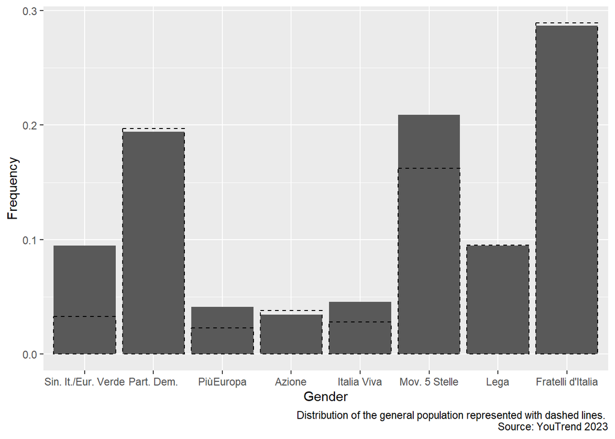

```r
# Visualization
temp_df %>% filter(POL_party != "Nessun partito" & POL_party != "Pref. non rispondere") %>%
  mutate(Frequency = GroupSum/sum(GroupSum)) %>%
  inner_join(select(genpop_df_PolPar, POL_party, GenPop), by = "POL_party") %>%
  ggplot(aes(x = POL_party, y = Frequency)) +
  geom_col() +
  geom_col(aes(y = GenPop), alpha = 0.25, linetype = "dashed", fill = NA, color = "black") +
  labs(x = "Gender", caption = "Distribution of the general population represented with dashed lines. \nSource: YouTrend 2023")
```

## PolOr

```r
var_n = "PolOr"
part_df[[var_n]] %>% table() %>% prop.table()
```

```
## .
##                  Sinistra                         1                         2
##                     0.075                     0.033                     0.057
##                         3                         4                         5
##                     0.087                     0.067                     0.162
##                         6                         7                         8
##                     0.102                     0.076                     0.075
##                         9                    Destra Preferisco non rispondere
##                     0.044                     0.090                     0.133
```

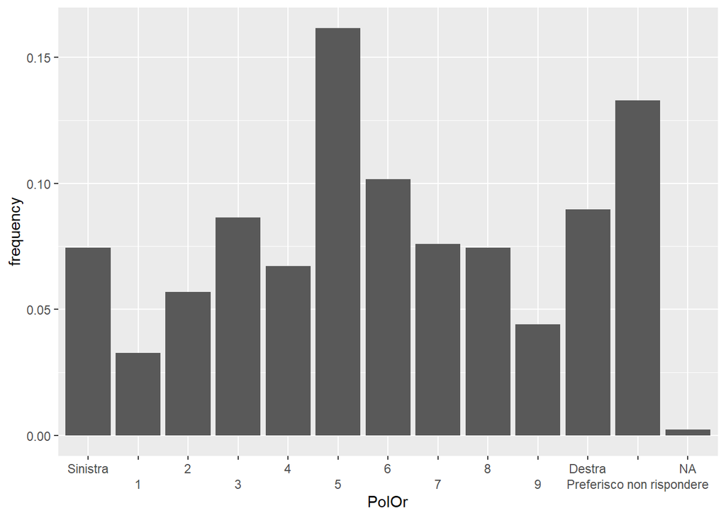

```r
part_df %>%
  ggplot(aes(x = .data[[var_n]])) +
  geom_bar(aes(y = (..count..)/sum(..count..))) +
  guides(x = guide_axis(n.dodge = 2)) +
  labs(x = var_n, y = "frequency")
```

### POL_OrNum

```r
var_n = "POL_OrNum"
part_df[[var_n]] %>% summary()
```

```
##    Min. 1st Qu.  Median    Mean 3rd Qu.    Max.    NA's
##       0       0       0       1       1       1     169
```

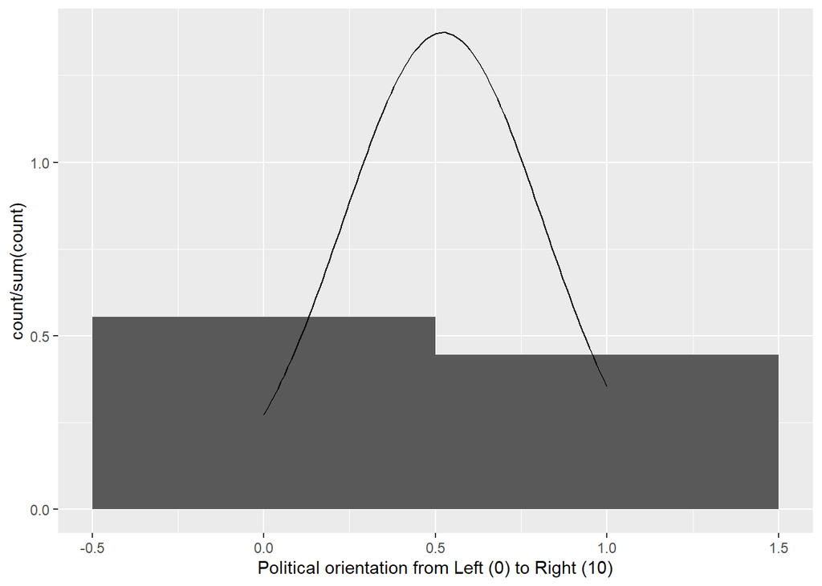

```r
part_df %>% ggplot(aes(x = part_df[[var_n]])) +
  geom_histogram(aes(y = after_stat(count/sum(count))), binwidth = 1) +
  stat_function(fun = ~dnorm(.x,
                             mean = mean(part_df[[var_n]], na.rm = T),
                             sd = sd(part_df[[var_n]], na.rm = T))) +
  labs(x = "Political orientation from Left (0) to Right (10)")
```

```r
part_df[[var_n]] %>% summary()
```

```
##    Min. 1st Qu.  Median    Mean 3rd Qu.    Max.    NA's
##       0       0       0       1       1       1     169
```

```r
sprintf("Mean: %.2f", mean(part_df[[var_n]], na.rm = T))
```

```
## [1] "Mean: 0.52"
```

```r
sprintf("Sd: %.2f", sd(part_df[[var_n]], na.rm = T))
```

```
## [1] "Sd: 0.29"
```

## Ideologies

### Redistribution

```r
myBarPlot <- function(var_n){
  ggplot(aes(x = .data[[var_n]]), data = part_df) +
  geom_bar(aes(y = (..count..)/sum(..count..))) +
  guides(x = guide_axis(n.dodge = 2)) +
  labs(x = var_n, y = "frequency") +
  scale_x_discrete(label = function(x) stringr::str_trunc(x, 30)) +
  coord_flip()
}

mySummary <- function(var_n){
  a <- sprintf("Summary of: %s", var_n)
  b <- part_df[[paste0(var_n, "Num")]] %>% summary()
  c <- sprintf("Mean: %.2f", mean(part_df[[paste0(var_n, "Num")]], na.rm = T))
  d <- sprintf("Sd: %.2f", sd(part_df[[paste0(var_n, "Num")]], na.rm = T))
  cat(a, "\n")
  print(b)
  cat(c, d)
}
```

```r
var_n = "POL3"
part_df[[var_n]] %>% table() %>% prop.table()
```

```
## .
##                        I redditi dovrebbero essere più eguali
##                                                         0.170
##                                                             1
##                                                         0.032
##                                                             2
##                                                         0.058
##                                                             3
##                                                         0.066
##                                                             4
##                                                         0.058
##                                                             5
##                                                         0.135
##                                                             6
##                                                         0.092
##                                                             7
##                                                         0.111
##                                                             8
##                                                         0.082
##                                                             9
##                                                         0.025
## Dovrebbero esserci più incentivi per l’iniziativa individuale
##                                                         0.139
##                                     Preferisco non rispondere
##                                                         0.030
```

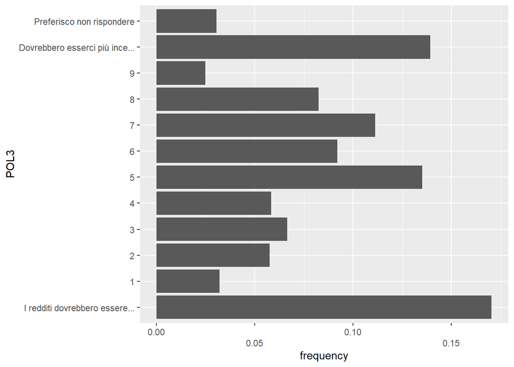

```r
myBarPlot(var_n)
```

```r
mySummary(var_n)
```

```
## Summary of: POL3
##    Min. 1st Qu.  Median    Mean 3rd Qu.    Max.    NA's
##       0       0       0       1       1       1      38
## Mean: 0.50 Sd: 0.33
```

### Well-being responsability

```r
var_n = "POL4"
part_df[[var_n]] %>% table() %>% prop.table()
```

```
## .
## Il governo dovrebbe prendersi più responsabilità nell’assicurare che ognuno abbia ciò di cui ha bisogno
##                                                                                                   0.239
##                                                                                                       1
##                                                                                                   0.050
##                                                                                                       2
##                                                                                                   0.062
##                                                                                                       3
##                                                                                                   0.098
##                                                                                                       4
##                                                                                                   0.061
##                                                                                                       5
##                                                                                                   0.128
##                                                                                                       6
##                                                                                                   0.080
##                                                                                                       7
##                                                                                                   0.083
##                                                                                                       8
##                                                                                                   0.071
##                                                                                                       9
##                                                                                                   0.050
##                               Le persone dovrebbero essere più responsabili di provvedere a loro stesse
##                                                                                                   0.063
##                                                                               Preferisco non rispondere
##                                                                                                   0.014
```

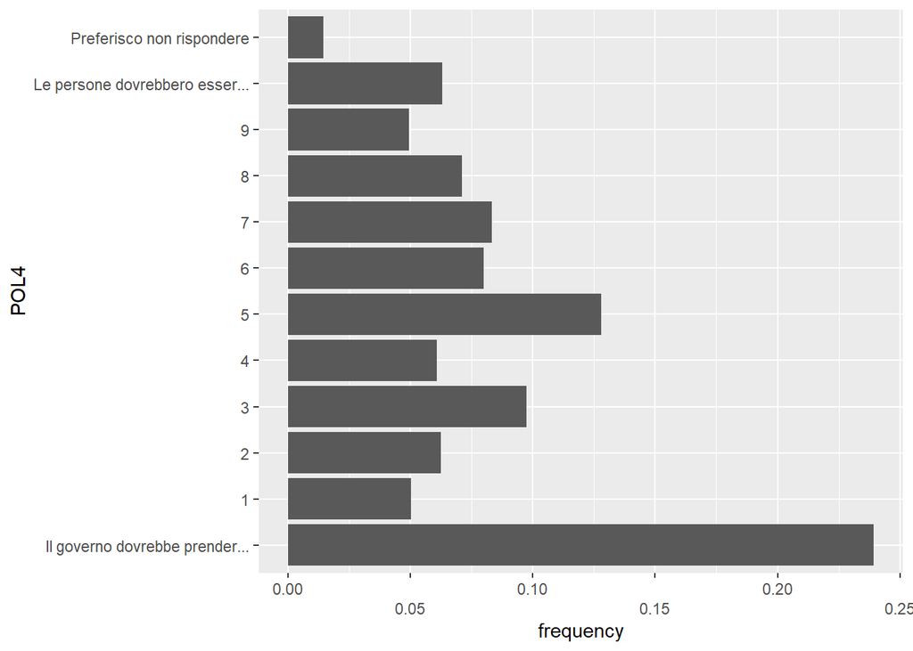

```r
myBarPlot(var_n)
```

```r
mySummary(var_n)
```

```
## Summary of: POL4
##    Min. 1st Qu.  Median    Mean 3rd Qu.    Max.    NA's
##     0.0     0.1     0.4     0.4     0.7     1.0      18
## Mean: 0.41 Sd: 0.33
```

### Moral Rules

```r
var_n = "POL5"
part_df[[var_n]] %>% table() %>% prop.table()
```

```
## .
##     Completamente d'accordo                           1
##                       0.107                       0.027
##                           2                           3
##                       0.050                       0.070
##                           4                           5
##                       0.076                       0.158
##                           6                           7
##                       0.078                       0.118
##                           8                           9
##                       0.092                       0.051
## Completamente in disaccordo   Preferisco non rispondere
##                       0.147                       0.026
```

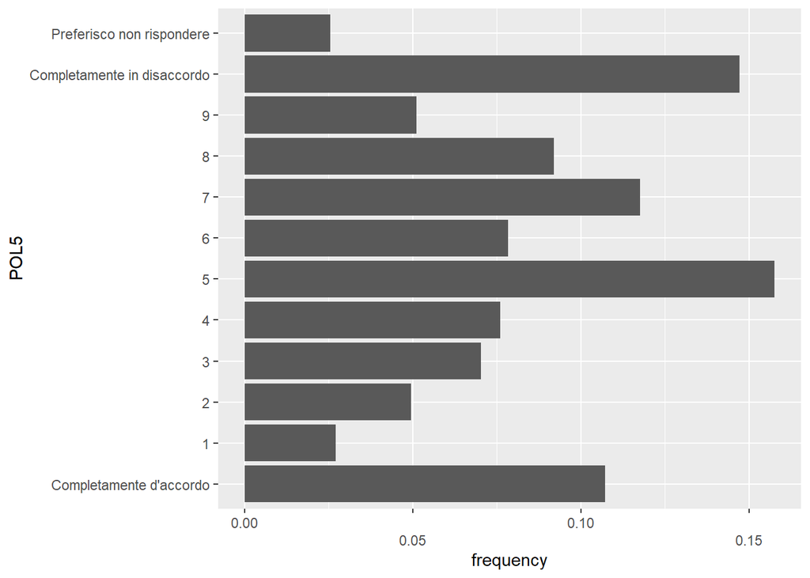

```r
myBarPlot(var_n)
```

```r
mySummary(var_n)
```

```
## Summary of: POL5
##    Min. 1st Qu.  Median    Mean 3rd Qu.    Max.    NA's
##       0       0       0       1       1       1      32
## Mean: 0.55 Sd: 0.31
```

### Importance of Democracy

```r
var_n = "POL6"
part_df[[var_n]] %>% table() %>% prop.table()
```

```
## .
##     Per niente importante                         1                         2
##                    0.0080                    0.0056                    0.0160
##                         3                         4                         5
##                    0.0144                    0.0264                    0.0592
##                         6                         7                         8
##                    0.0665                    0.0697                    0.1081
##                         9   Estremamente importante Preferisco non rispondere
##                    0.0969                    0.5020                    0.0272
```

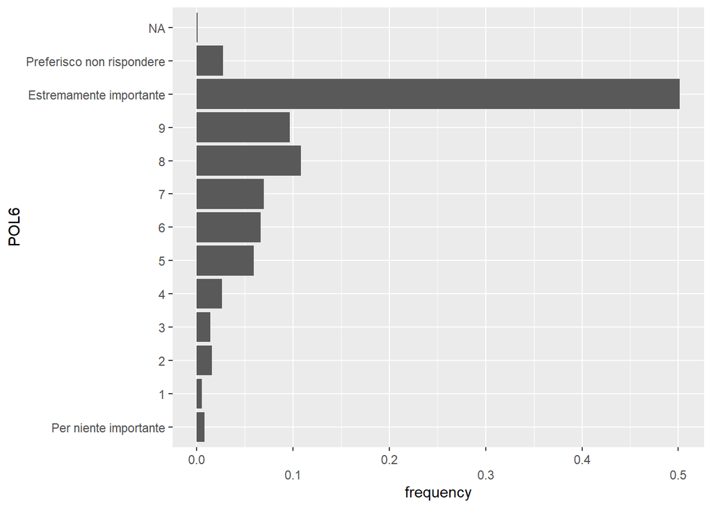

```r
myBarPlot(var_n)
```

```r
mySummary(var_n)
```

```
## Summary of: POL6
##    Min. 1st Qu.  Median    Mean 3rd Qu.    Max.    NA's
##       0       1       1       1       1       1      35
## Mean: 0.84 Sd: 0.23
```

## Correlation Matrix and possible index

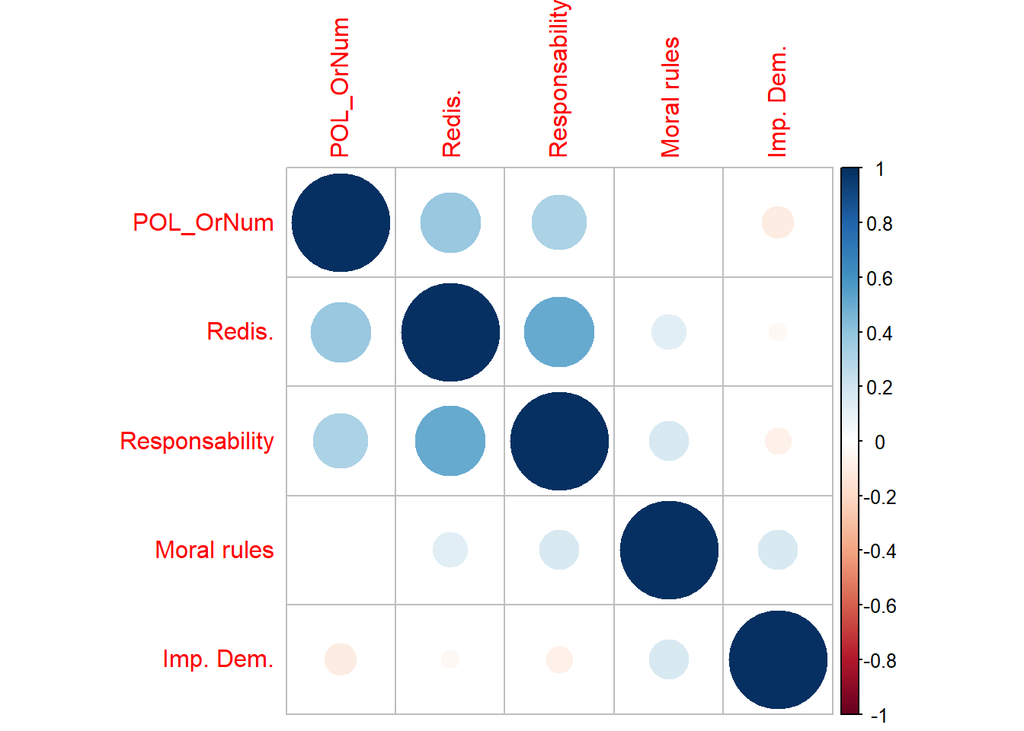

```r
temp_df <- part_df %>% select(POL_OrNum:POL6Num) %>% cor(use = "complete.obs")
colnames(temp_df) <- c("POL_OrNum", "Redis.", "Responsability", "Moral rules", "Imp. Dem.")
rownames(temp_df) <- c("POL_OrNum", "Redis.", "Responsability", "Moral rules", "Imp. Dem.")
temp_df %>% corrplot::corrplot()
```

# Institutional Trust

## Institutions

### “Preferisco non rispondere” for each institution

```r
var_n = "INST.Press"
var_i = match(var_n, names(part_df))
for (i in var_i:(var_i + 4)) {
  temp_df <- part_df[,i] %>% table() %>% prop.table()
  cat(sprintf("%s: %s\n", names(part_df)[i], temp_df[11]))
}
```

```
## INST.Press: 0.0112179487179487
## INST.Parliament: 0.0176282051282051
## INST.Government: 0.016025641025641
## INST.SocialMedia: 0.0120192307692308
## INST.Universities: 0.0176423416198877
```

### Trust in institutions

```r
my_plot <- function(data, x){
  p <- ggplot(data,
         aes(x = .data[[x]])) +
    geom_bar() +
    theme(legend.position = "none") +
    ylim(0,270)
  #return(p)
}

var_n = "IT_Press"
var_i = match(var_n, names(part_df))

inst <- names(part_df)[var_i:(var_i + 4)]

l <- lapply(inst, my_plot, data = part_df)
```

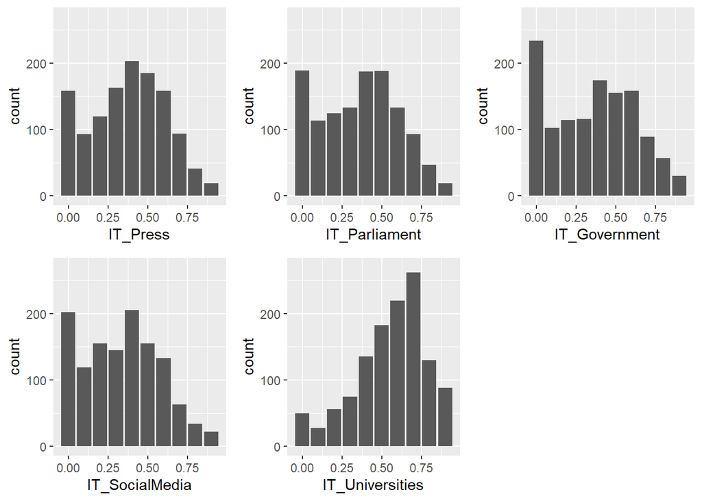

```r
ggpubr::ggarrange(l[[1]], l[[2]], l[[3]], l[[4]],
                  l[[5]],
                  ncol=3, nrow=2, common.legend = TRUE, legend="bottom") %>% print()
```

### Index

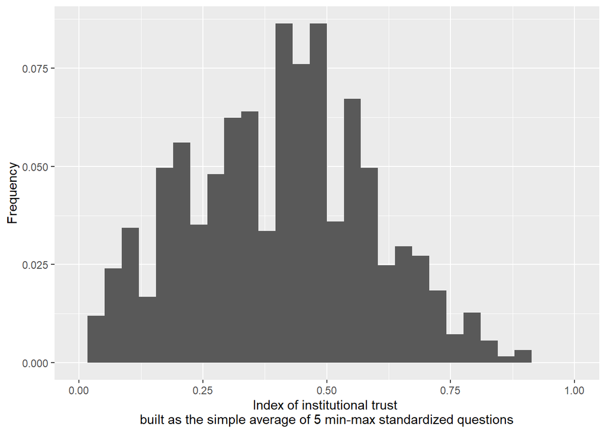

```r
var_n = "inst_tr"
part_df %>% ggplot(aes(x = inst_tr)) +
  geom_histogram(aes(y = after_stat(count/sum(count)))) +
  xlim(0,1) +
  labs(x = "Index of institutional trust \nbuilt as the simple average of 5 min-max standardized questions",
       y = "Frequency")
```

```r
part_df %>% select(IT_Press:IT_Universities, inst_tr) %>% summary()
```

```
##  IT_Press.INST_1 IT_Parliament.INST_2 IT_Government.INST_3
##  Min.   :0.0     Min.   :0.0          Min.   :0.0
##  1st Qu.:0.2     1st Qu.:0.2          1st Qu.:0.1
##  Median :0.4     Median :0.4          Median :0.4
##  Mean   :0.4     Mean   :0.4          Mean   :0.4
##  3rd Qu.:0.6     3rd Qu.:0.5          3rd Qu.:0.6
##  Max.   :0.9     Max.   :0.9          Max.   :0.9
##  NA's   :16      NA's   :24           NA's   :22
##  IT_SocialMedia.INST_4 IT_Universities.INST_5    inst_tr
##  Min.   :0.0           Min.   :0.0            Min.   :0.00
##  1st Qu.:0.1           1st Qu.:0.4            1st Qu.:0.24
##  Median :0.3           Median :0.6            Median :0.40
##  Mean   :0.3           Mean   :0.6            Mean   :0.39
##  3rd Qu.:0.5           3rd Qu.:0.7            3rd Qu.:0.52
##  Max.   :0.9           Max.   :0.9            Max.   :0.90
##  NA's   :17            NA's   :25
```

```r
cat("\n\nStandard Deviations: \n")
```

```
##
##
## Standard Deviations:
```

```r
part_df %>% select(IT_Press:IT_Universities, inst_tr) %>% lapply(sd, na.rm = T)
```

```
## $IT_Press
## [1] 0.23
##
## $IT_Parliament
## [1] 0.24
##
## $IT_Government
## [1] 0.26
##
## $IT_SocialMedia
## [1] 0.24
##
## $IT_Universities
## [1] 0.22
##
## $inst_tr
## [1] 0.19
```

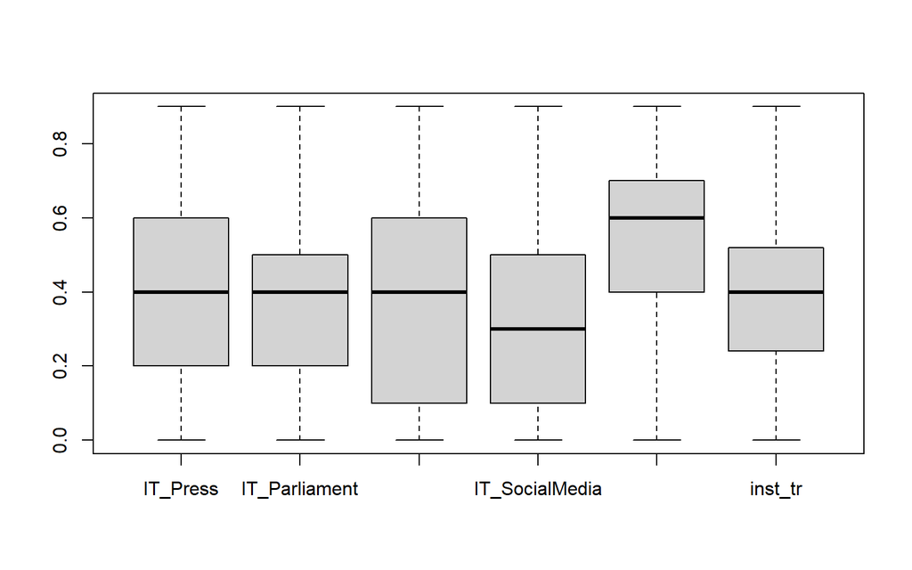

```r
part_df %>% select(IT_Press:IT_Universities, inst_tr) %>% boxplot()
```

## Science

### SCI1 - Life better off

```r
var_n = "SCI1"
part_df[[var_n]] %>% table() %>% prop.table()
```

```
## .
##          Non sono per niente d'accordo                     Non sono d'accordo
##                                 0.0280                                 0.0488
##         Sono leggermente in disaccordo Non sono né d'accordo né in disaccordo
##                                 0.0656                                 0.1568
##             Sono leggermente d'accordo                         Sono d'accordo
##                                 0.2144                                 0.3304
##              Sono pienamente d'accordo              Preferisco non rispondere
##                                 0.1488                                 0.0072
```

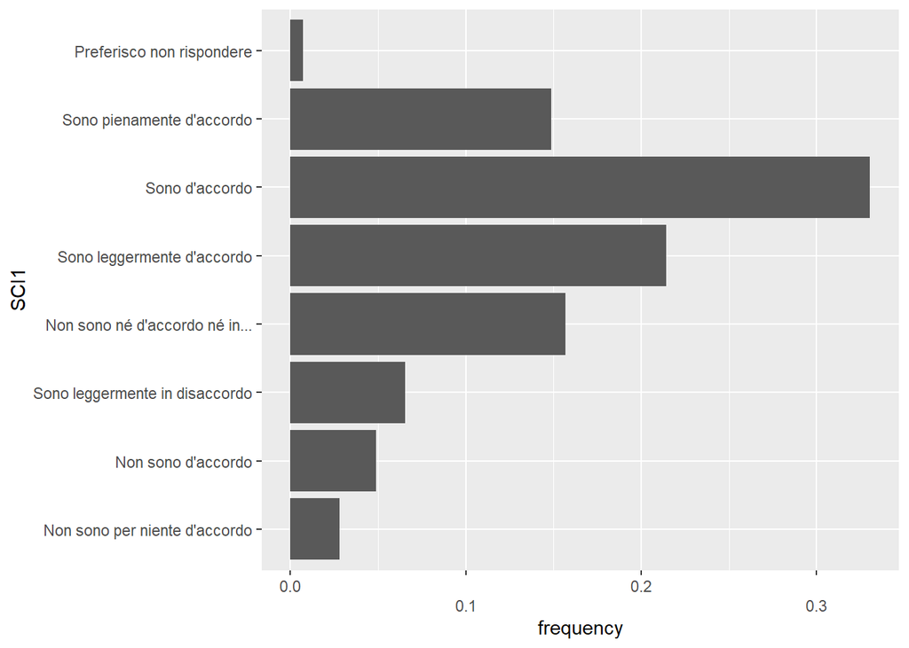

```r
myBarPlot(var_n)
```

```r
mySummary(var_n)
```

```
## Summary of: SCI1
##    Min. 1st Qu.  Median    Mean 3rd Qu.    Max.    NA's
##     0.0     3.0     4.0     4.1     5.0     6.0       9
## Mean: 4.08 Sd: 1.50
```

### SCI2 - World better off

```r
var_n = "SCI2"
part_df[[var_n]] %>% table() %>% prop.table()
```

```
## .
##              Molto peggio                         2                         3
##                     0.038                     0.014                     0.028
##                         4                         5                         6
##                     0.050                     0.102                     0.140
##                         7                         8                         9
##                     0.167                     0.187                     0.077
##              Molto meglio Preferisco non rispondere
##                     0.185                     0.013
```

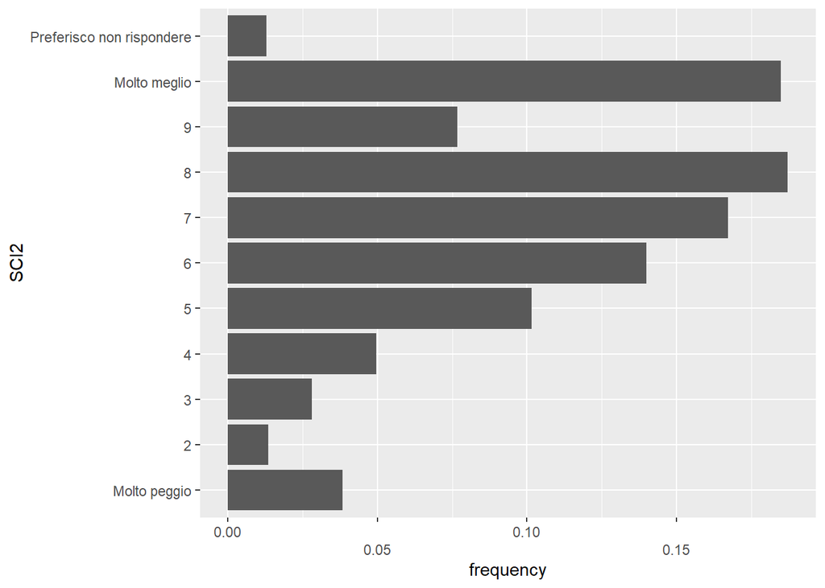

```r
myBarPlot(var_n)
```

```r
mySummary(var_n)
```

```
## Summary of: SCI2
##    Min. 1st Qu.  Median    Mean 3rd Qu.    Max.    NA's
##       0       5       6       6       8       9      16
## Mean: 5.99 Sd: 2.32
```

## Correlation matrix

```r
temp_df <- part_df %>% select(IT_Press:inst_tr, ANTIEL1Num:ANTIELIndex) %>% cor(use = "complete.obs")
temp_df
```

```
##                 IT_Press IT_Parliament IT_Government IT_SocialMedia
## IT_Press           1.000         0.668         0.600          0.531
## IT_Parliament      0.668         1.000         0.826          0.488
## IT_Government      0.600         0.826         1.000          0.451
## IT_SocialMedia     0.531         0.488         0.451          1.000
## IT_Universities    0.543         0.503         0.420          0.365
## inst_tr            0.838         0.883         0.840          0.711
## ANTIEL1Num        -0.112        -0.229        -0.262         -0.129
## ANTIEL2Num        -0.028        -0.046        -0.058         -0.061
## ANTIEL3Num        -0.410        -0.489        -0.485         -0.364
## ANTIELIndex       -0.293        -0.396        -0.413         -0.288
##                 IT_Universities inst_tr ANTIEL1Num ANTIEL2Num ANTIEL3Num
## IT_Press                  0.543   0.838     -0.112     -0.028     -0.410
## IT_Parliament             0.503   0.883     -0.229     -0.046     -0.489
## IT_Government             0.420   0.840     -0.262     -0.058     -0.485
## IT_SocialMedia            0.365   0.711     -0.129     -0.061     -0.364
## IT_Universities           1.000   0.701      0.043      0.073     -0.220
## inst_tr                   0.701   1.000     -0.179     -0.033     -0.499
## ANTIEL1Num                0.043  -0.179      1.000      0.330      0.269
## ANTIEL2Num                0.073  -0.033      0.330      1.000      0.091
## ANTIEL3Num               -0.220  -0.499      0.269      0.091      1.000
## ANTIELIndex              -0.075  -0.374      0.724      0.635      0.723
##                 ANTIELIndex
## IT_Press             -0.293
## IT_Parliament        -0.396
## IT_Government        -0.413
## IT_SocialMedia       -0.288
## IT_Universities      -0.075
## inst_tr              -0.374
## ANTIEL1Num            0.724
## ANTIEL2Num            0.635
## ANTIEL3Num            0.723
## ANTIELIndex           1.000
```

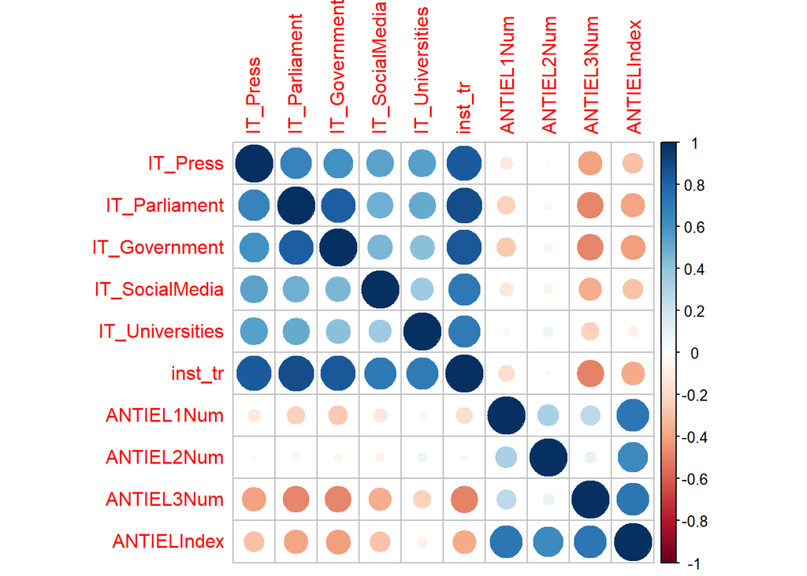

```r
temp_df %>% corrplot::corrplot()
```

## Anti-Elitism

### “Preferisco non rispondere” per question

```r
var_n = "ANTIEL_1"
var_i = match(var_n, names(part_df))
for (i in var_i:(var_i + 2)) {
  temp_df <- part_df[,i] %>% table() %>% prop.table()
  cat(sprintf("%s: %s\n", names(part_df)[i], temp_df[8]))
}
```

```
## ANTIEL_1: 0.0168
## ANTIEL_2: 0.0240384615384615
## ANTIEL_3: 0.00880704563650921
```

### Visualization

1- Talk too much

2- Difference between people vs elite

3- Think about people

```r
lbls <- list("ANTIEL1Num" = "I politici parlano troppo...",
          "ANTIEL2Num" ="La differenza tra le persone...",
          "ANTIEL3Num" ="I politici ascoltano...(reversed)",
          "ANTIELIndex" ="Anti-elitism Index")

my_plot <- function(data, x){
  p <- ggplot(data,
         aes(x = .data[[x]])) +
    geom_histogram(aes(y = after_stat(count/sum(count)))) +
    theme(legend.position = "none") +
    ylim(0,0.5) +
    #xlim(0,1.2) +
    labs(x = lbls[[x]],
         y = "Frequency")
  #return(p)
}

var_n = "ANTIEL1Num"
var_i = match(var_n, names(part_df))

vars <- names(part_df)[var_i:(var_i + 4)]

l <- lapply(vars, my_plot, data = part_df)
```

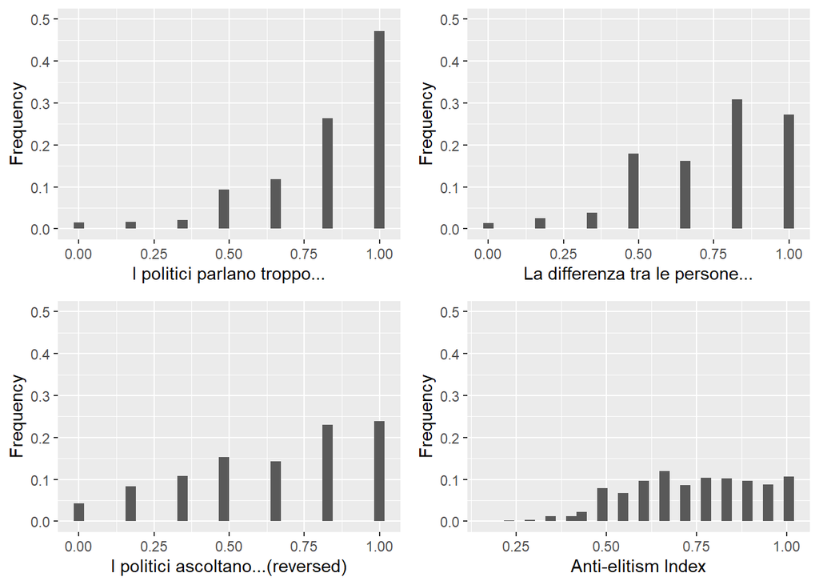

```r
ggpubr::ggarrange(l[[1]], l[[2]], l[[3]], l[[4]],
                  ncol=2, nrow=2, common.legend = TRUE, legend="bottom") %>% print()
```

## Numerical Summary

```r
part_df %>% select(ANTIEL1Num:ANTIELIndex) %>% summary()
```

```
##    ANTIEL1Num    ANTIEL2Num   ANTIEL3Num   ANTIELIndex
##  Min.   :0.0   Min.   :0    Min.   :0.0   Min.   :0
##  1st Qu.:0.7   1st Qu.:0    1st Qu.:0.5   1st Qu.:1
##  Median :0.8   Median :1    Median :0.7   Median :1
##  Mean   :0.8   Mean   :1    Mean   :0.7   Mean   :1
##  3rd Qu.:1.0   3rd Qu.:1    3rd Qu.:0.8   3rd Qu.:1
##  Max.   :1.0   Max.   :1    Max.   :1.0   Max.   :1
##  NA's   :21    NA's   :32   NA's   :12    NA's   :44
```

```r
cat("\n\nStandard Deviations: \n")
```

```
##
##
## Standard Deviations:
```

```r
part_df %>% select(ANTIEL1Num:ANTIELIndex) %>% lapply(sd, na.rm = T)
```

```
## $ANTIEL1Num
## [1] 0.22
##
## $ANTIEL2Num
## [1] 0.23
##
## $ANTIEL3Num
## [1] 0.3
##
## $ANTIELIndex
## [1] 0.17
```

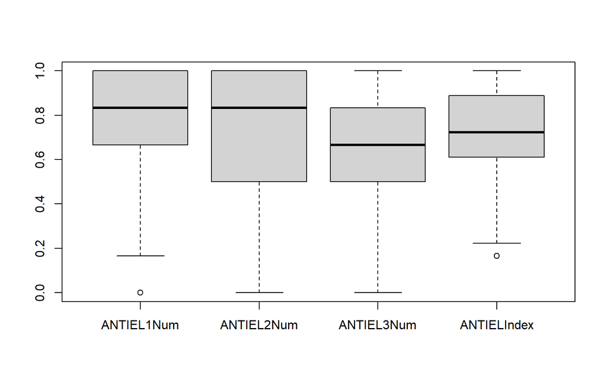

```r
part_df %>% select(ANTIEL1Num:ANTIELIndex) %>% boxplot()
```

# Social Norms

## 0 - Missing Cases

```r
sum(is.na(part_df$SOCNORM1_1))
```

```
## [1] 38
```

```r
sum(is.na(part_df$SOCNORM2))
```

```
## [1] 0
```

```r
sum(is.na(part_df$SOCNORM3_1))
```

```
## [1] 38
```

```r
sum(is.na(part_df$SOCNORM4))
```

```
## [1] 0
```

## 1 - Factual Beliefs

### First Priority

```r
table(part_df$SOCNORM1_1) %>% prop.table() %>% sort(decreasing = T)
```

```
##
##   Interesting      Accurate         Funny All. Politics    Surprising
##         0.356         0.356         0.107         0.100         0.081
```

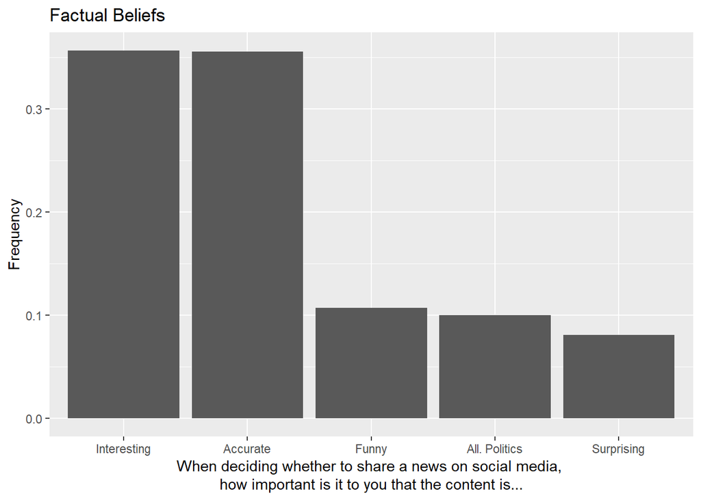

```r
l[[1]] <- part_df %>% filter(!is.na(SOCNORM1_1)) %>% ggplot(aes(x = fct_infreq(SOCNORM1_1))) +
  geom_bar(aes(y = after_stat(count/sum(count)))) +
  labs(title = "Factual Beliefs", x = "When deciding whether to share a news on social media,
       \nhow important is it to you that the content is...",
       y = "Frequency") + th
l[[1]]
```

### All ranking

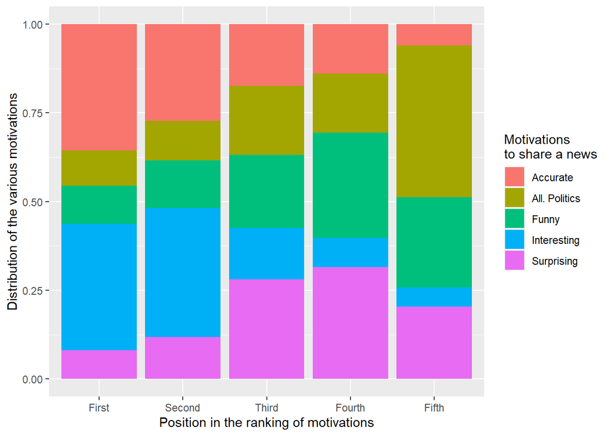

```r
part_df %>% select(id, SOCNORM1_1:SOCNORM1_5) %>%
  pivot_longer(cols = -id,
               names_to = c(".value", "rank"),
               names_sep = "_",
               values_drop_na = T) %>%
  ggplot(aes(x = as.factor(rank), fill = SOCNORM1)) +
  geom_bar(position = "fill") +
  labs(x = "Position in the ranking of motivations",
       y = "Distribution of the various motivations") +
  scale_fill_discrete(name = "Motivations \nto share a news") +
  scale_x_discrete(labels = c("First", "Second", "Third", "Fourth", "Fifth"))
```